# Birth Volume and Cesarean Delivery Rates in Brazil — analyses of the Supplementary Material

Revised manuscript IJG-D-26-02002: Supplementary Tables S1–S9 and Figures S1–S2

## Packages, helpers and data

```r
library(readr); library(dplyr); library(tidyr); library(ggplot2); library(cowplot); library(lme4); library(knitr)
fmt  <- function(x, d = 1) formatC(x, format = "f", digits = d, big.mark = ",")
n_   <- function(x) formatC(x, format = "d", big.mark = ",")
pval <- function(p) ifelse(p < 0.001, "<0.001", sprintf("%.3f", p))
NAVY <- "#1f3864"; RED <- "#a33a3a"
tema <- theme_classic(base_size = 11) +
  theme(panel.grid.major.y = element_line(colour = "#eeeeee"),
        plot.title = element_text(colour = NAVY, hjust = 0.5, size = 11), axis.text = element_text(colour = "black"))
YEARS <- c(2018, 2019, 2022, 2023, 2024)
ctrl  <- glmerControl(optimizer = "bobyqa", optCtrl = list(maxfun = 2e5))
conv  <- function(m) if (is.null(m@optinfo$conv$lme4$messages)) "OK" else paste(m@optinfo$conv$lme4$messages, collapse = "; ")

# data/facility_years.csv: one row per facility-year with >=1 live birth in the study years (SINASC), without volume restriction
BANDS <- c("100 - 499", "500 - 999", "1000 - 1499", "1500 - 1999", ">1999")
fyall <- read_csv("data/facility_years.csv", col_types = cols(cnes = "c", cod_mun = "c"))
allf <- fyall |> mutate(rate = 100 * cesareans / live_births)
# Eligible facility-years (>=100 live births); `included` = complete cases used in the main model
eleg <- fyall |> filter(eligible) |>
  mutate(included = included_main_model,
         volume_band = as.character(cut(live_births, c(100, 500, 1000, 1500, 2000, Inf), right = FALSE, labels = BANDS)))
d <- eleg |> filter(included) |> mutate(rate = 100 * cesareans / live_births)
# Facilities with births in the excluded pandemic years (SINASC; used only in the flowchart)
fy <- tibble(year = c(2018, 2019, 2020, 2021, 2022, 2023, 2024),
             facilities_with_births = c(5531, 5500, 5501, 5549, 5566, 5456, 5368))
stopifnot(all(fy$facilities_with_births[fy$year %in% YEARS] == as.integer(table(allf$year))))
stopifnot(nrow(d) == 12104, nrow(allf) == 27421, all(sort(unique(allf$year)) == YEARS))
```

# S1. Study sample

## Figure S1. Flowchart of the selection of facility-years

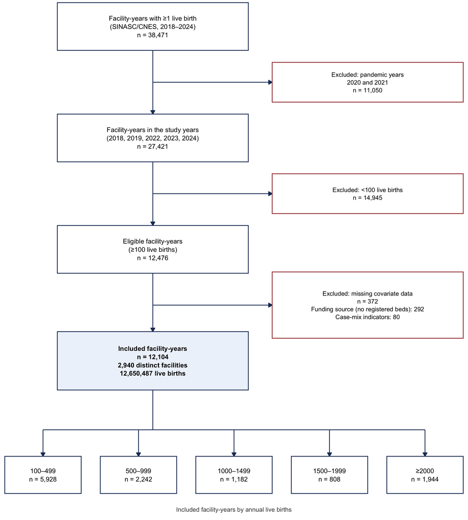

```r
n_total <- sum(fy$facilities_with_births)
n_pand  <- sum(fy$facilities_with_births[fy$year %in% c(2020, 2021)])
n_lt100 <- sum(allf$live_births < 100)
excl    <- eleg |> filter(!included)
n_beds  <- sum(is.na(excl$beds))
stopifnot(n_total - n_pand == nrow(allf), nrow(allf) - n_lt100 == nrow(eleg))
bands <- table(factor(d$volume_band, c("100 - 499", "500 - 999", "1000 - 1499", "1500 - 1999", ">1999")))
caixas <- tibble::tribble(
  ~x, ~y, ~w, ~h, ~borda, ~fundo, ~negrito, ~rotulo,
  33, 93, 40, 9, NAVY, "white", FALSE, sprintf("Facility-years with ≥1 live birth\n(SINASC/CNES, 2018–2024)\nn = %s", n_(n_total)),
  33, 72, 40, 9, NAVY, "white", FALSE, sprintf("Facility-years in the study years\n(2018, 2019, 2022, 2023, 2024)\nn = %s", n_(n_total - n_pand)),
  33, 51, 40, 9, NAVY, "white", FALSE, sprintf("Eligible facility-years\n(≥100 live births)\nn = %s", n_(nrow(eleg))),
  33, 30, 40, 11, NAVY, "#eef3fa", TRUE, sprintf("Included facility-years\nn = %s\n%s distinct facilities\n%s live births",
                                                 n_(nrow(d)), n_(n_distinct(d$cnes)), n_(sum(d$live_births))),
  78, 82.5, 40, 7.5, RED, "white", FALSE, sprintf("Excluded: pandemic years\n2020 and 2021\nn = %s", n_(n_pand)),
  78, 61.5, 40, 7.5, RED, "white", FALSE, sprintf("Excluded: <100 live births\nn = %s", n_(n_lt100)),
  78, 40.5, 40, 12.5, RED, "white", FALSE, sprintf("Excluded: missing covariate data\nn = %s\nFunding source (no registered beds): %s\nCase-mix indicators: %s",
                                                  n_(nrow(excl)), n_(n_beds), n_(nrow(excl) - n_beds))) |>
  bind_rows(tibble(x = c(10, 30, 50, 70, 90), y = 8.5, w = 16, h = 7, borda = NAVY, fundo = "white", negrito = FALSE,
                   rotulo = sprintf("%s\nn = %s", c("100–499", "500–999", "1000–1499", "1500–1999", "≥2000"), n_(as.integer(bands)))))
setas <- tibble::tribble(~x, ~y, ~xend, ~yend, 33, 88.5, 33, 76.5, 33, 67.5, 33, 55.5, 33, 46.5, 33, 35.5,
                         33, 82.5, 58, 82.5, 33, 61.5, 58, 61.5, 33, 40.5, 58, 40.5) |>
  bind_rows(tibble(x = c(10, 30, 50, 70, 90), y = 17, xend = c(10, 30, 50, 70, 90), yend = 12))
ggplot() +
  geom_segment(data = tibble::tribble(~x, ~y, ~xend, ~yend, 33, 24.5, 33, 17, 10, 17, 90, 17),
               aes(x, y, xend = xend, yend = yend), colour = NAVY, linewidth = 0.5) +
  geom_segment(data = setas, aes(x, y, xend = xend, yend = yend), colour = NAVY, linewidth = 0.5,
               arrow = arrow(length = unit(2, "mm"), type = "closed")) +
  geom_rect(data = caixas, aes(xmin = x - w / 2, xmax = x + w / 2, ymin = y - h / 2, ymax = y + h / 2),
            fill = caixas$fundo, colour = caixas$borda, linewidth = 0.5) +
  geom_text(data = caixas, aes(x, y, label = rotulo, fontface = ifelse(negrito, "bold", "plain")),
            size = ifelse(caixas$borda == RED, 3.0, 3.2), lineheight = 1.05) +
  annotate("text", x = 50, y = 2, label = "Included facility-years by annual live births", size = 3, colour = "#444444") +
  coord_cartesian(xlim = c(1, 99), ylim = c(0, 98), expand = FALSE) + theme_void()
```

## Table S1. Facilities with live births by year

```r
s1 <- allf |> group_by(Year = year) |>
  summarise(`Facilities with births, n` = n(), `≥100 births (eligible), n` = sum(live_births >= 100),
            `<100 births (excluded), n` = sum(live_births < 100), .groups = "drop") |>
  left_join(d |> count(Year = year, name = "Included in models (complete cases), n"), by = "Year") |>
  select(Year, `Facilities with births, n`, `≥100 births (eligible), n`, `Included in models (complete cases), n`, `<100 births (excluded), n`)
s1 <- bind_rows(s1 |> mutate(Year = as.character(Year)),
                s1 |> summarise(across(-Year, sum)) |> mutate(Year = "Total (facility-years)"))
kable(s1 |> mutate(across(-Year, n_)))
```

| Year | Facilities with births, n | ≥100 births (eligible), n | Included in models (complete cases), n | <100 births (excluded), n |
| --- | --- | --- | --- | --- |
| 2018 | 5,531 | 2,668 | 2,584 | 2,863 |
| 2019 | 5,500 | 2,628 | 2,534 | 2,872 |
| 2022 | 5,566 | 2,459 | 2,393 | 3,107 |
| 2023 | 5,456 | 2,404 | 2,338 | 3,052 |
| 2024 | 5,368 | 2,317 | 2,255 | 3,051 |
| Total (facility-years) | 27,421 | 12,476 | 12,104 | 14,945 |

# S2. Rationale for the threshold of 100 live births per year

```r
BRK <- c(0, 10, 25, 50, 100, 200, 500, 1000, 2000, Inf)
LAB <- c("1–9", "10–24", "25–49", "50–99", "100–199", "200–499", "500–999", "1000–1999", "≥2000")
allf <- allf |> mutate(bin = cut(live_births, BRK, right = FALSE, labels = LAB))
```

## Table S2. Distribution of facility-years and cesarean rates by annual volume band (study years pooled)

```r
s2 <- allf |> group_by(`Live births per year` = bin) |>
  summarise(n = n(), b = sum(live_births), pz = 100 * mean(cesareans == 0), med = median(rate),
            w = 100 * sum(cesareans) / sum(live_births), .groups = "drop") |>
  transmute(`Live births per year`, `Facility-years, n` = n_(n), `Live births, n` = n_(b),
            `% of facility-years` = fmt(100 * n / sum(n)), `% with no cesarean` = fmt(pz),
            `Median rate, %` = fmt(med), `Birth-weighted rate, %` = fmt(w))
kable(s2)
```

| Live births per year | Facility-years, n | Live births, n | % of facility-years | % with no cesarean | Median rate, % | Birth-weighted rate, % |
| --- | --- | --- | --- | --- | --- | --- |
| 1–9 | 9,215 | 23,352 | 33.6 | 81.4 | 0.0 | 17.0 |
| 10–24 | 1,822 | 29,216 | 6.6 | 57.5 | 0.0 | 33.5 |
| 25–49 | 1,656 | 59,667 | 6.0 | 38.9 | 58.6 | 48.6 |
| 50–99 | 2,252 | 163,503 | 8.2 | 25.5 | 70.3 | 55.6 |
| 100–199 | 2,669 | 389,487 | 9.7 | 11.4 | 76.0 | 64.9 |
| 200–499 | 3,492 | 1,134,622 | 12.7 | 2.9 | 73.5 | 68.3 |
| 500–999 | 2,308 | 1,639,526 | 8.4 | 0.1 | 69.3 | 67.0 |
| 1000–1999 | 2,044 | 2,942,384 | 7.5 | 0.0 | 61.5 | 61.8 |
| ≥2000 | 1,963 | 6,774,752 | 7.2 | 0.0 | 51.4 | 53.4 |

```r
tibble(`Facility-years with ≥1 live birth` = n_(nrow(allf)),
       `with ≥100 live births` = sprintf("%s (%s%%)", n_(sum(allf$live_births >= 100)), fmt(100 * mean(allf$live_births >= 100))),
       `% of live births in facilities with ≥100` = fmt(100 * sum(allf$live_births[allf$live_births >= 100]) / sum(allf$live_births)),
       `100–199 band: facility-years with ≥1 cesarean, %` = fmt(100 * mean(allf$cesareans[allf$bin == "100–199"] > 0))) |>
  pivot_longer(everything(), names_to = "Item", values_to = "Value") |> kable()
```

| Item | Value |
| --- | --- |
| Facility-years with ≥1 live birth | 27,421 |
| with ≥100 live births | 12,476 (45.5%) |
| % of live births in facilities with ≥100 | 97.9 |
| 100–199 band: facility-years with ≥1 cesarean, % | 88.6 |

## Table S3. Birth-weighted cesarean rate (%) by annual volume band and year

```r
s3 <- allf |> group_by(bin, year) |> summarise(w = 100 * sum(cesareans) / sum(live_births), .groups = "drop")
kable(s3 |> mutate(w = fmt(w)) |> pivot_wider(names_from = year, values_from = w) |> rename(`Live births per year` = bin))
```

| Live births per year | 2018 | 2019 | 2022 | 2023 | 2024 |
| --- | --- | --- | --- | --- | --- |
| 1–9 | 18.6 | 16.8 | 18.1 | 15.6 | 16.1 |
| 10–24 | 31.7 | 36.8 | 30.4 | 35.2 | 33.4 |
| 25–49 | 48.4 | 49.1 | 46.7 | 46.2 | 52.6 |
| 50–99 | 55.4 | 54.9 | 52.9 | 56.0 | 59.0 |
| 100–199 | 61.4 | 61.5 | 64.5 | 67.6 | 70.2 |
| 200–499 | 64.9 | 65.9 | 69.0 | 70.8 | 71.3 |
| 500–999 | 65.1 | 65.6 | 66.9 | 69.0 | 68.8 |
| 1000–1999 | 61.5 | 60.3 | 61.8 | 62.8 | 62.9 |
| ≥2000 | 51.3 | 52.0 | 53.7 | 55.0 | 56.3 |

## Table S4. Effect of alternative volume thresholds (study years pooled)

```r
s4 <- bind_rows(lapply(c(25, 50, 75, 100, 150, 200, 300), function(k) {
  keep <- allf$live_births >= k
  tibble(`Threshold (births/year)` = paste0("≥", k),
         `Facilities per year, mean` = n_(round(sum(keep) / length(YEARS))),
         `% of facilities retained` = fmt(100 * mean(keep)),
         `% of births retained` = fmt(100 * sum(allf$live_births[keep]) / sum(allf$live_births)),
         `% with no cesarean among excluded` = fmt(100 * mean(allf$cesareans[!keep] == 0)),
         `Median rate above threshold, %` = fmt(median(allf$rate[keep])))
}))
kable(s4)
```

| Threshold (births/year) | Facilities per year, mean | % of facilities retained | % of births retained | % with no cesarean among excluded | Median rate above threshold, % |
| --- | --- | --- | --- | --- | --- |
| ≥25 | 3,277 | 59.7 | 99.6 | 77.5 | 66.3 |
| ≥50 | 2,946 | 53.7 | 99.1 | 72.4 | 66.6 |
| ≥75 | 2,696 | 49.2 | 98.6 | 68.6 | 66.4 |
| ≥100 | 2,495 | 45.5 | 97.9 | 65.4 | 66.2 |
| ≥150 | 2,200 | 40.1 | 96.5 | 60.8 | 65.4 |
| ≥200 | 1,961 | 35.8 | 94.9 | 57.2 | 64.4 |
| ≥300 | 1,649 | 30.1 | 92.0 | 52.9 | 63.0 |

## Table S5. Follow-up of facilities with fewer than 100 live births in 2019 and 2024

```r
coorte <- function(ref) {
  ids <- allf$cnes[allf$year == ref & allf$live_births < 100]
  cc  <- allf |> filter(cnes %in% ids)
  sempre <- cc |> group_by(cnes) |> summarise(s = all(live_births < 100), .groups = "drop")
  r <- allf |> filter(year == ref, cnes %in% ids)
  resumo <- tibble(Cohort = ref, n = n_(length(ids)), `Always <100 births, %` = fmt(100 * mean(sempre$s)),
                   `Median births in reference year` = median(r$live_births), `Mean` = fmt(mean(r$live_births)),
                   `1–24 births, %` = fmt(100 * mean(r$live_births < 25)), `75–99 births, %` = fmt(100 * mean(r$live_births >= 75)))
  tab <- cc |> group_by(Year = year) |>
    summarise(`Facilities in the cohort with births, n` = n_(n()), `Still <100 births, %` = fmt(100 * mean(live_births < 100)),
              `Median births in the year` = median(live_births), .groups = "drop") |> mutate(Cohort = ref, .before = 1)
  list(resumo = resumo, tab = tab)
}
c19 <- coorte(2019); c24 <- coorte(2024)
kable(bind_rows(c19$resumo, c24$resumo))
```

| Cohort | n | Always <100 births, % | Median births in reference year | Mean | 1–24 births, % | 75–99 births, % |
| --- | --- | --- | --- | --- | --- | --- |
| 2019 | 2,872 | 91.7 | 4 | 18.5 | 73.9 | 7.2 |
| 2024 | 3,051 | 83.7 | 4 | 18.0 | 74.1 | 5.9 |

```r
kable(bind_rows(c19$tab, c24$tab))
```

| Cohort | Year | Facilities in the cohort with births, n | Still <100 births, % | Median births in the year |
| --- | --- | --- | --- | --- |
| 2019 | 2018 | 2,072 | 93.4 | 13 |
| 2019 | 2019 | 2,872 | 100.0 | 4 |
| 2019 | 2022 | 1,875 | 95.0 | 10 |
| 2019 | 2023 | 1,829 | 94.9 | 9 |
| 2019 | 2024 | 1,747 | 94.6 | 8 |
| 2024 | 2018 | 1,978 | 79.5 | 25 |
| 2024 | 2019 | 2,020 | 81.8 | 21 |
| 2024 | 2022 | 2,166 | 90.3 | 15 |
| 2024 | 2023 | 2,269 | 93.9 | 11 |
| 2024 | 2024 | 3,051 | 100.0 | 4 |

## Figure S2. Cesarean rate and facility-years with no cesarean by volume band

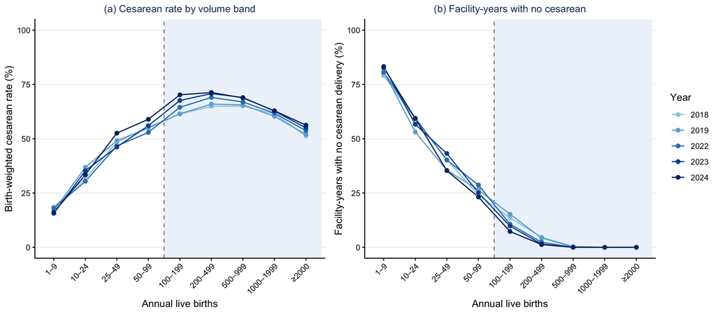

```r
fs2 <- allf |> group_by(year, bin) |>
  summarise(w = 100 * sum(cesareans) / sum(live_births), z = 100 * mean(cesareans == 0), .groups = "drop") |>
  mutate(year = factor(year))
pal <- setNames(c("#9ecae1", "#6baed6", "#3182bd", "#08519c", "#08306b"), YEARS)
painel <- function(y, ylab, titulo)
  ggplot(fs2, aes(bin, .data[[y]], colour = year, group = year)) +
    annotate("rect", xmin = 4.5, xmax = 9.5, ymin = -Inf, ymax = Inf, fill = "#eef3fa") +
    geom_vline(xintercept = 4.5, linetype = "dashed", colour = "grey50") +
    geom_line(linewidth = 0.6) + geom_point(size = 1.8) +
    scale_colour_manual(values = pal, name = "Year") + scale_y_continuous(limits = c(0, 100)) +
    labs(x = "Annual live births", y = ylab, title = titulo) + tema + theme(axis.text.x = element_text(angle = 45, hjust = 1))
plot_grid(painel("w", "Birth-weighted cesarean rate (%)", "(a) Cesarean rate by volume band") + theme(legend.position = "none"),
          painel("z", "Facility-years with no cesarean delivery (%)", "(b) Facility-years with no cesarean"),
          ncol = 2, rel_widths = c(1, 1.18), align = "h", axis = "bt")
```

# S3. Additional model results

```r
COMB <- c("SUS No" = "Public (SUS), not accredited", "SUS Yes" = "Public (SUS), accredited",
          "Misto No" = "Mixed, not accredited", "Misto Yes" = "Mixed, accredited", "Privado No" = "Private, not accredited")
dm <- d |> mutate(comb = relevel(factor(COMB[paste(beds, high_risk)], COMB), ref = "Public (SUS), not accredited"),
                  typ = relevel(factor(typology), ref = "Rural"), obs = factor(row_number()))
```

## Table S6. Funding source among accredited facilities, by year

```r
hab <- dm |> filter(high_risk == "Yes")
s6 <- hab |> count(Year = year, beds) |> pivot_wider(names_from = beds, values_from = n, values_fill = 0) |>
  mutate(Year = as.character(Year))
s6 <- bind_rows(s6, s6 |> summarise(across(-Year, sum)) |> mutate(Year = "Total"))
if (!"Privado" %in% names(s6)) s6$Privado <- 0
s6 |> mutate(Total = SUS + Misto + Privado,
             `Public (SUS), n (%)` = sprintf("%s (%s)", n_(SUS), fmt(100 * SUS / Total)),
             `Mixed, n (%)` = sprintf("%s (%s)", n_(Misto), fmt(100 * Misto / Total)),
             `Private, n (%)` = sprintf("%s (%s)", n_(Privado), fmt(100 * Privado / Total)),
             `Total, n` = n_(Total)) |>
  select(Year, `Public (SUS), n (%)`, `Mixed, n (%)`, `Private, n (%)`, `Total, n`) |> kable()
```

| Year | Public (SUS), n (%) | Mixed, n (%) | Private, n (%) | Total, n |
| --- | --- | --- | --- | --- |
| 2018 | 49 (25.8) | 141 (74.2) | 0 (0.0) | 190 |
| 2019 | 60 (30.5) | 137 (69.5) | 0 (0.0) | 197 |
| 2022 | 64 (28.8) | 158 (71.2) | 0 (0.0) | 222 |
| 2023 | 73 (32.9) | 149 (67.1) | 0 (0.0) | 222 |
| 2024 | 80 (36.0) | 142 (64.0) | 0 (0.0) | 222 |
| Total | 326 (31.0) | 727 (69.0) | 0 (0.0) | 1,053 |

```r
hab |> count(`Annual live births` = factor(volume_band, c("100 - 499", "500 - 999", "1000 - 1499", "1500 - 1999", ">1999"))) |>
  mutate(`%` = fmt(100 * n / sum(n))) |> kable(caption = "Accredited facility-years by annual live births (table footnote)")
```

Accredited facility-years by annual live births (table footnote)

| Annual live births | n | % |
| --- | --- | --- |
| 100 - 499 | 3 | 0.3 |
| 500 - 999 | 41 | 3.9 |
| 1000 - 1499 | 112 | 10.6 |
| 1500 - 1999 | 166 | 15.8 |
| >1999 | 731 | 69.4 |

## Table S7. Annual volume as a continuous exposure (log2 scale)

Same model as Table 3 of the main text, with log2-transformed annual volume in place of the volume categories.

```r
m7 <- glmer(cbind(cesareans, live_births - cesareans) ~ log2(live_births) + comb + typ + hdi_state + pct_black_brown +
              pct_previous_cesarean + (1 | cod_mun) + (1 | uf) + (1 | obs), data = dm, family = binomial, control = ctrl)
cat("Convergence:", conv(m7), "\n")
```

```
## Convergence: OK
```

```r
co <- summary(m7)$coefficients
tibble(term = rownames(co), b = co[, 1], se = co[, 2], p = co[, 4]) |> filter(term != "(Intercept)") |>
  mutate(k = ifelse(term == "hdi_state", 0.1, 1), dig = ifelse(grepl("^pct_", term), 3, 2),
         OR = mapply(fmt, exp(b * k), dig),
         `95% CI` = paste0(mapply(fmt, exp((b - 1.96 * se) * k), dig), "–", mapply(fmt, exp((b + 1.96 * se) * k), dig)),
         `p-value` = pval(p),
         term = term |> recode(`log2(live_births)` = "Annual live births, per doubling", hdi_state = "State HDI (per 0.1)",
                               pct_black_brown = "Black or brown mothers, % (per 1 percentage point)",
                               pct_previous_cesarean = "Mothers with a previous cesarean, % (per 1 percentage point)") |>
           sub("^comb", "", x = _) |> sub("^typ", "Municipal typology: ", x = _)) |>
  select(Predictor = term, OR, `95% CI`, `p-value`) |> kable()
```

| Predictor | OR | 95% CI | p-value |
| --- | --- | --- | --- |
| Annual live births, per doubling | 0.84 | 0.82–0.85 | <0.001 |
| Public (SUS), accredited | 1.61 | 1.46–1.77 | <0.001 |
| Mixed, not accredited | 1.87 | 1.78–1.97 | <0.001 |
| Mixed, accredited | 1.55 | 1.43–1.68 | <0.001 |
| Private, not accredited | 3.98 | 3.72–4.25 | <0.001 |
| Municipal typology: Intermediario | 1.16 | 0.98–1.37 | 0.093 |
| Municipal typology: Urbano | 1.71 | 1.47–1.97 | <0.001 |
| State HDI (per 0.1) | 1.68 | 1.51–1.86 | <0.001 |
| Black or brown mothers, % (per 1 percentage point) | 0.988 | 0.986–0.989 | <0.001 |
| Mothers with a previous cesarean, % (per 1 percentage point) | 1.057 | 1.055–1.059 | <0.001 |

## Table S8. Facility type × high-risk accreditation within each annual volume band (unadjusted)

```r
s8 <- bind_rows(lapply(c("500 - 999", "1000 - 1499", "1500 - 1999", ">1999"), function(f) {
  df <- dm |> filter(volume_band == f) |> droplevels() |> mutate(comb = relevel(comb, ref = "Public (SUS), not accredited"))
  desc <- df |> group_by(comb) |> summarise(n = n(), w = 100 * sum(cesareans) / sum(live_births), .groups = "drop")
  m <- glmer(cbind(cesareans, live_births - cesareans) ~ comb + (1 | obs), data = df, family = binomial, control = ctrl)
  b <- fixef(m); V <- as.matrix(vcov(m))
  ct <- function(pos, neg = NULL) { L <- setNames(rep(0, length(b)), names(b)); L[pos] <- 1; if (!is.null(neg)) L[neg] <- -1
    e <- sum(L * b); s <- sqrt(drop(t(L) %*% V %*% L)); c(exp(e), exp(e - 1.96 * s), exp(e + 1.96 * s), 2 * pnorm(-abs(e / s))) }
  a <- ct("combPublic (SUS), accredited"); mm <- ct("combMixed, accredited", "combMixed, not accredited")
  tibble(`Annual live births` = f,
         `Counts n (birth-weighted rate %)` = paste(sprintf("%s: %s (%s)", desc$comb, n_(desc$n), fmt(desc$w)), collapse = "; "),
         `Public accredited vs public not accredited` = sprintf("%.2f (%.2f–%.2f), p %s", a[1], a[2], a[3], pval(a[4])),
         `Mixed accredited vs mixed not accredited` = sprintf("%.2f (%.2f–%.2f), p %s", mm[1], mm[2], mm[3], pval(mm[4])),
         Convergence = conv(m))
}))
kable(s8)
```

| Annual live births | Counts n (birth-weighted rate %) | Public accredited vs public not accredited | Mixed accredited vs mixed not accredited | Convergence |
| --- | --- | --- | --- | --- |
| 500 - 999 | Public (SUS), not accredited: 657 (51.4); Public (SUS), accredited: 16 (66.2); Mixed, not accredited: 1,134 (68.5); Mixed, accredited: 25 (65.5); Private, not accredited: 410 (86.3) | 1.90 (1.12–3.24), p 0.018 | 0.75 (0.49–1.15), p 0.183 | OK |
| 1000 - 1499 | Public (SUS), not accredited: 296 (48.5); Public (SUS), accredited: 30 (54.6); Mixed, not accredited: 569 (63.0); Mixed, accredited: 82 (59.1); Private, not accredited: 205 (83.0) | 1.24 (0.87–1.77), p 0.234 | 0.73 (0.59–0.91), p 0.006 | OK |
| 1500 - 1999 | Public (SUS), not accredited: 131 (45.0); Public (SUS), accredited: 35 (49.8); Mixed, not accredited: 396 (60.9); Mixed, accredited: 131 (59.4); Private, not accredited: 115 (82.9) | 1.22 (0.89–1.66), p 0.211 | 0.84 (0.71–0.99), p 0.041 | OK |
| >1999 | Public (SUS), not accredited: 286 (41.9); Public (SUS), accredited: 242 (46.5); Mixed, not accredited: 676 (51.3); Mixed, accredited: 489 (53.4); Private, not accredited: 251 (76.5) | 1.19 (1.06–1.34), p 0.003 | 1.08 (0.99–1.16), p 0.071 | OK |

## Table S9. Sensitivity analysis including facilities with fewer than 100 annual live births

Facility-years of `data/facility_years.csv` with `in_sensitivity = TRUE`: all facility-years with at least one live birth in the study years and complete data for the reduced model (funding source and accreditation are not available in CNES for many of the smallest facilities). The same reduced model fitted to facility-years with at least 100 live births is shown for comparison.

```r
sens <- fyall |> filter(in_sensitivity) |>
  mutate(band = relevel(factor(cut(live_births, c(0, 100, 500, 1000, 1500, 2000, Inf), right = FALSE,
                                   labels = c("<100", "100–499", "500–999", "1000–1499", "1500–1999", "≥2000"))), ref = "≥2000"),
         typ = relevel(factor(typology), ref = "Rural"))
f9 <- cbind(cesareans, live_births - cesareans) ~ band + typ + hdi_state + pct_black_brown + pct_previous_cesarean +
  (1 | cod_mun) + (1 | uf) + (1 | obs)
fit9 <- function(df) glmer(f9, data = df |> mutate(obs = factor(row_number())), family = binomial, control = ctrl)
mT <- fit9(sens); m1 <- fit9(sens |> filter(live_births >= 100) |> droplevels() |> mutate(band = relevel(band, ref = "≥2000")))
tid <- function(m, amostra) { co <- summary(m)$coefficients; k <- grepl("^band", rownames(co))
  tibble(Sample = sprintf("%s (n = %s)", amostra, n_(nobs(m))), `Annual live births` = sub("band", "", rownames(co)[k]),
         OR = fmt(exp(co[k, 1]), 2), `95% CI` = paste0(fmt(exp(co[k, 1] - 1.96 * co[k, 2]), 2), "–", fmt(exp(co[k, 1] + 1.96 * co[k, 2]), 2)),
         `p-value` = pval(co[k, 4]), Convergence = conv(m)) }
kable(bind_rows(tid(mT, "All facility-years with ≥1 live birth"), tid(m1, "Facility-years with ≥100 live births")))
```

| Sample | Annual live births | OR | 95% CI | p-value | Convergence |
| --- | --- | --- | --- | --- | --- |
| All facility-years with ≥1 live birth (n = 25,706) | <100 | 1.10 | 1.02–1.18 | 0.009 | OK |
| All facility-years with ≥1 live birth (n = 25,706) | 100–499 | 2.42 | 2.25–2.59 | <0.001 | OK |
| All facility-years with ≥1 live birth (n = 25,706) | 500–999 | 1.65 | 1.53–1.78 | <0.001 | OK |
| All facility-years with ≥1 live birth (n = 25,706) | 1000–1499 | 1.27 | 1.17–1.38 | <0.001 | OK |
| All facility-years with ≥1 live birth (n = 25,706) | 1500–1999 | 1.12 | 1.03–1.22 | 0.008 | OK |
| Facility-years with ≥100 live births (n = 12,155) | 100–499 | 2.75 | 2.58–2.93 | <0.001 | OK |
| Facility-years with ≥100 live births (n = 12,155) | 500–999 | 1.92 | 1.80–2.04 | <0.001 | OK |
| Facility-years with ≥100 live births (n = 12,155) | 1000–1499 | 1.44 | 1.35–1.54 | <0.001 | OK |
| Facility-years with ≥100 live births (n = 12,155) | 1500–1999 | 1.21 | 1.13–1.29 | <0.001 | OK |